# NBA Player Statistics: Exploratory Data Analysis

This notebook explores a dataset of NBA player statistics to uncover insights about player performance, draft outcomes, physical attributes, and more.

## 1. Setup and Data Loading

```python
import pandas as pd
import numpy as np
import matplotlib.pyplot as plt
import seaborn as sns
from pandasql import sqldf  # For running SQL queries on pandas DataFrames
```

```python
# Setup for pandasql
pysqldf = lambda q: sqldf(q, globals())

# Plotting preferences
sns.set_style("whitegrid")
plt.rcParams['figure.figsize'] = (12, 7)
plt.rcParams['font.size'] = 12
```

```python
# Load the dataset
try:
    df = pd.read_csv('../data/PlayerIndex_nba_stats.csv')
except FileNotFoundError:
    df = pd.read_csv('data/PlayerIndex_nba_stats.csv') # Fallback for running directly in notebooks folder

print("Dataset Loaded. Shape:", df.shape)
df.head()
```

```
Dataset Loaded. Shape: (5025, 26)
```

|  | PERSON_ID | PLAYER_LAST_NAME | PLAYER_FIRST_NAME | PLAYER_SLUG | TEAM_ID | TEAM_SLUG | IS_DEFUNCT | TEAM_CITY | TEAM_NAME | TEAM_ABBREVIATION | ... | DRAFT_YEAR | DRAFT_ROUND | DRAFT_NUMBER | ROSTER_STATUS | PTS | REB | AST | STATS_TIMEFRAME | FROM_YEAR | TO_YEAR |
| --- | --- | --- | --- | --- | --- | --- | --- | --- | --- | --- | --- | --- | --- | --- | --- | --- | --- | --- | --- | --- | --- |
| 0 | 76001 | Abdelnaby | Alaa | alaa-abdelnaby | 1610612757 | blazers | 0 | Portland | Trail Blazers | POR | ... | 1990.0 | 1.0 | 25.0 | NaN | 5.7 | 3.3 | 0.3 | Career | 1990 | 1994 |
| 1 | 76002 | Abdul-Aziz | Zaid | zaid-abdul-aziz | 1610612745 | rockets | 0 | Houston | Rockets | HOU | ... | 1968.0 | 1.0 | 5.0 | NaN | 9.0 | 8.0 | 1.2 | Career | 1968 | 1977 |
| 2 | 76003 | Abdul-Jabbar | Kareem | kareem-abdul-jabbar | 1610612747 | lakers | 0 | Los Angeles | Lakers | LAL | ... | 1969.0 | 1.0 | 1.0 | NaN | 24.6 | 11.2 | 3.6 | Career | 1969 | 1988 |
| 3 | 51 | Abdul-Rauf | Mahmoud | mahmoud-abdul-rauf | 1610612743 | nuggets | 0 | Denver | Nuggets | DEN | ... | 1990.0 | 1.0 | 3.0 | NaN | 14.6 | 1.9 | 3.5 | Career | 1990 | 2000 |
| 4 | 1505 | Abdul-Wahad | Tariq | tariq-abdul-wahad | 1610612758 | kings | 0 | Sacramento | Kings | SAC | ... | 1997.0 | 1.0 | 11.0 | NaN | 7.8 | 3.3 | 1.1 | Career | 1997 | 2003 |

5 rows × 26 columns

## 2. Data Cleaning and Preprocessing

```python
print("Initial data types:\n", df.dtypes)
print("\nMissing values before cleaning:\n", df.isnull().sum())


# Combine First and Last Name
df['PLAYER_NAME'] = df['PLAYER_FIRST_NAME'] + ' ' + df['PLAYER_LAST_NAME']

# Function to convert height (e.g., "6-10") to inches
def height_to_inches(height_str):
    if pd.isna(height_str) or not isinstance(height_str, str) or '-' not in height_str:
        return np.nan
    try:
        feet, inches = map(int, height_str.split('-'))
        return feet * 12 + inches
    except ValueError:
        return np.nan

df['HEIGHT_INCHES'] = df['HEIGHT'].apply(height_to_inches)

# Convert WEIGHT to numeric, handling potential non-numeric entries
df['WEIGHT_LBS'] = pd.to_numeric(df['WEIGHT'], errors='coerce')

# Convert PTS, REB, AST to numeric, coercing errors
for col in ['PTS', 'REB', 'AST']:
    df[col] = pd.to_numeric(df[col], errors='coerce')

# Handle missing numerical stats (PTS, REB, AST) - fill with 0 or mean/median
# For this EDA, filling with 0 might be acceptable if we assume missing means no recorded stat.
# Alternatively, drop rows or impute. Let's fill with 0 for simplicity in aggregation.
df[['PTS', 'REB', 'AST']] = df[['PTS', 'REB', 'AST']].fillna(0)

# Handle missing DRAFT_NUMBER - important for draft analysis
# We can fill NaN DRAFT_NUMBER with a high value (e.g., max_draft_pick + 1) or a specific category for "Undrafted"
# For numerical analysis, a high number might skew things. Let's create an 'IS_UNDRAFTED' column.
df['DRAFT_NUMBER'] = pd.to_numeric(df['DRAFT_NUMBER'], errors='coerce')
df['IS_UNDRAFTED'] = df['DRAFT_NUMBER'].isnull()
# Fill NaN DRAFT_NUMBER with a value that indicates undrafted if we want to keep it numeric for some plots
# Or, for draft-specific analysis, we might drop these NaNs.
# For now, let's keep NaNs for DRAFT_NUMBER and use IS_UNDRAFTED for categorical.

# Clean up categorical columns
for col in ['POSITION', 'COLLEGE', 'COUNTRY']:
    df[col] = df[col].fillna('Unknown')

# Drop original HEIGHT and WEIGHT columns as we have numeric versions
df.drop(columns=['HEIGHT', 'WEIGHT'], inplace=True)

print("\nMissing values after cleaning:\n", df.isnull().sum())
df.describe(include=[np.number])


df.info()
```

```
Initial data types:
 PERSON_ID              int64
PLAYER_LAST_NAME      object
PLAYER_FIRST_NAME     object
PLAYER_SLUG           object
TEAM_ID                int64
TEAM_SLUG             object
IS_DEFUNCT             int64
TEAM_CITY             object
TEAM_NAME             object
TEAM_ABBREVIATION     object
JERSEY_NUMBER         object
POSITION              object
HEIGHT                object
WEIGHT               float64
COLLEGE               object
COUNTRY               object
DRAFT_YEAR           float64
DRAFT_ROUND          float64
DRAFT_NUMBER         float64
ROSTER_STATUS        float64
PTS                  float64
REB                  float64
AST                  float64
STATS_TIMEFRAME       object
FROM_YEAR              int64
TO_YEAR                int64
dtype: object

Missing values before cleaning:
 PERSON_ID               0
PLAYER_LAST_NAME        0
PLAYER_FIRST_NAME       1
PLAYER_SLUG             0
TEAM_ID                 0
TEAM_SLUG             266
IS_DEFUNCT              0
TEAM_CITY               0
TEAM_NAME               0
TEAM_ABBREVIATION       0
```

[output cut: 68 more lines]

```
 15  DRAFT_ROUND        3502 non-null   float64
 16  DRAFT_NUMBER       3434 non-null   float64
 17  ROSTER_STATUS      534 non-null    float64
 18  PTS                5025 non-null   float64
 19  REB                5025 non-null   float64
 20  AST                5025 non-null   float64
 21  STATS_TIMEFRAME    5025 non-null   object
 22  FROM_YEAR          5025 non-null   int64
 23  TO_YEAR            5025 non-null   int64
 24  PLAYER_NAME        5024 non-null   object
 25  HEIGHT_INCHES      4978 non-null   float64
 26  WEIGHT_LBS         4972 non-null   float64
 27  IS_UNDRAFTED       5025 non-null   bool
dtypes: bool(1), float64(9), int64(5), object(13)
memory usage: 1.0+ MB
```

## 3. Exploratory Data Analysis (EDA)

### 3.1 Overall Player Statistics (Focus on Career Stats for broader view)

For a general overview, let's look at players with 'Career' stats. For active players, 'Season' reflects their latest season, which is also interesting.

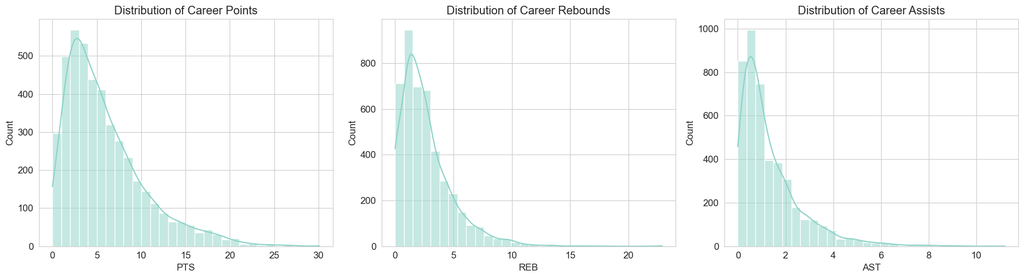

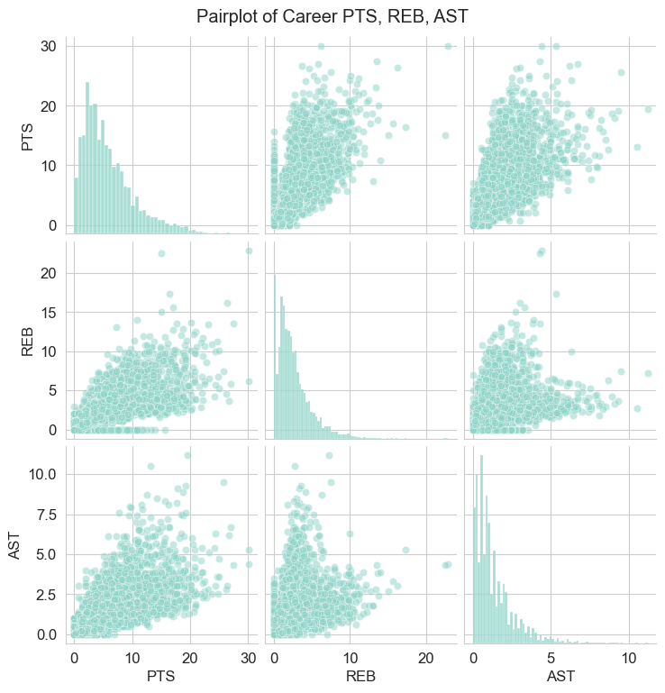

```python
career_df = df[df['STATS_TIMEFRAME'] == 'Career'].copy()
season_df = df[df['STATS_TIMEFRAME'] == 'Season'].copy() # Latest season for active players


# Distributions of key career stats
fig, axes = plt.subplots(1, 3, figsize=(18, 5))
sns.histplot(career_df['PTS'], kde=True, ax=axes[0], bins=30)
axes[0].set_title('Distribution of Career Points')
sns.histplot(career_df['REB'], kde=True, ax=axes[1], bins=30)
axes[1].set_title('Distribution of Career Rebounds')
sns.histplot(career_df['AST'], kde=True, ax=axes[2], bins=30)
axes[2].set_title('Distribution of Career Assists')
plt.tight_layout()
plt.show()


# Relationship between PTS, REB, AST (Career)
sns.pairplot(career_df[['PTS', 'REB', 'AST']].dropna(), kind='scatter', plot_kws={'alpha':0.5})
plt.suptitle('Pairplot of Career PTS, REB, AST', y=1.02)
plt.show()
```

3.2 Positional Analysis

```python
# Average stats by position (using all data, acknowledging Career/Season mix)
position_stats = df.groupby('POSITION')[['PTS', 'REB', 'AST', 'HEIGHT_INCHES', 'WEIGHT_LBS']].mean().sort_values(by='PTS', ascending=False)
print("Average Stats by Position:\n", position_stats)
```

```
Average Stats by Position:
                PTS       REB       AST  HEIGHT_INCHES  WEIGHT_LBS
POSITION
F-G       8.519753  3.185185  1.725926      78.666667  217.370370
C-F       7.537719  5.187719  1.120175      82.359649  249.850877
G-F       7.106633  2.586224  1.501531      78.061224  211.622449
F-C       6.872857  4.467143  1.023571      82.035714  242.878571
G         6.461704  1.773255  2.089784      74.859343  189.695786
F         5.994951  3.077223  0.977827      79.246019  217.992303
C         5.760947  4.078698  0.843047      82.766272  242.146884
Unknown   3.391667  0.302083  0.750000      78.500000  215.000000
```

```
Average Stats by Position:
                PTS       REB       AST  HEIGHT_INCHES  WEIGHT_LBS
POSITION
F-G       8.519753  3.185185  1.725926      78.666667  217.370370
C-F       7.537719  5.187719  1.120175      82.359649  249.850877
G-F       7.106633  2.586224  1.501531      78.061224  211.622449
F-C       6.872857  4.467143  1.023571      82.035714  242.878571
G         6.461704  1.773255  2.089784      74.859343  189.695786
F         5.994951  3.077223  0.977827      79.246019  217.992303
C         5.760947  4.078698  0.843047      82.766272  242.146884
Unknown   3.391667  0.302083  0.750000      78.500000  215.000000
```

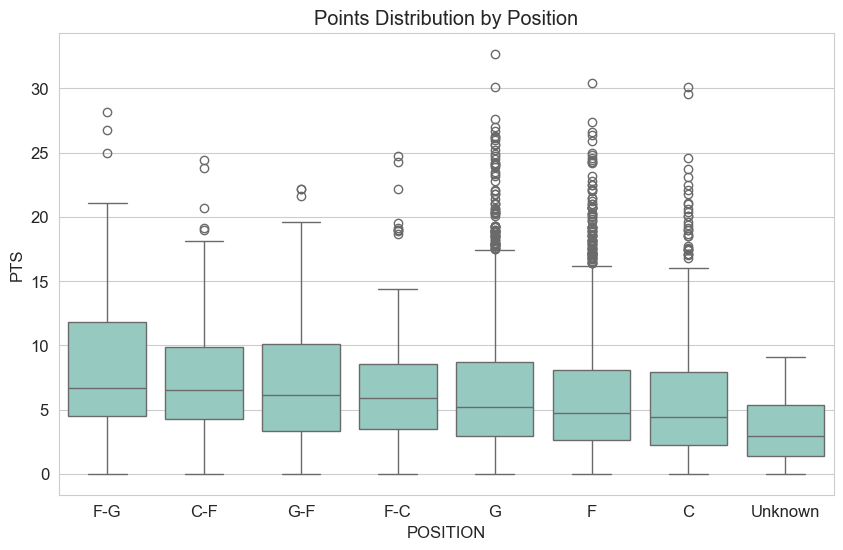

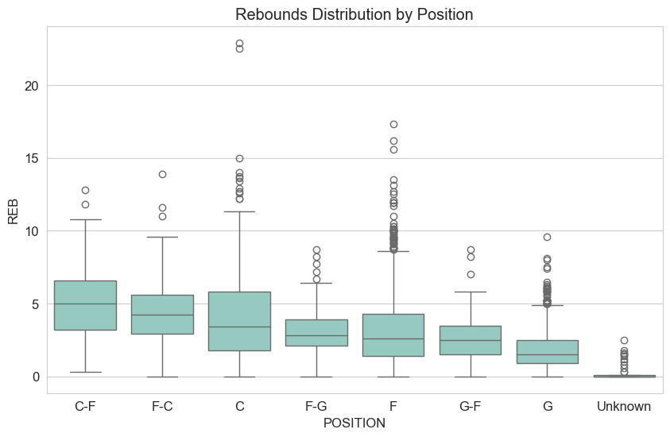

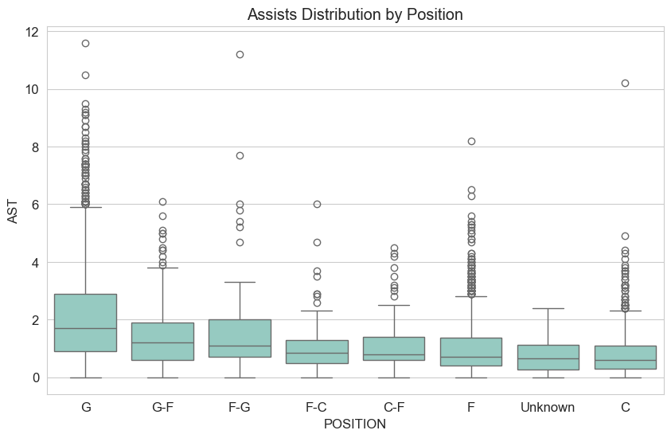

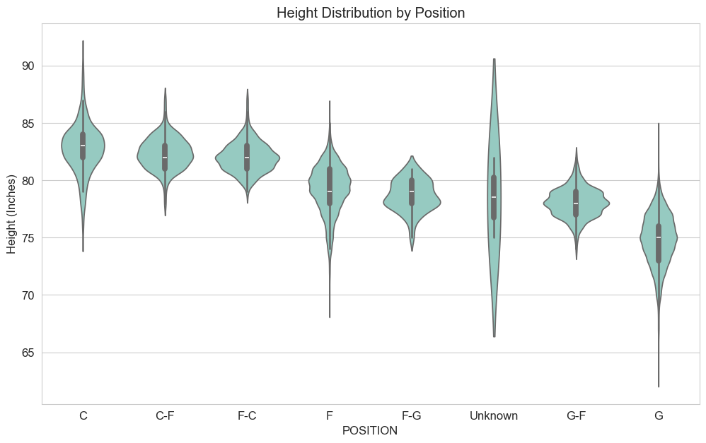

```python
# Average stats by position (using all data, acknowledging Career/Season mix)
position_stats = df.groupby('POSITION')[['PTS', 'REB', 'AST', 'HEIGHT_INCHES', 'WEIGHT_LBS']].mean().sort_values(by='PTS', ascending=False)
print("Average Stats by Position:\n", position_stats)

# Boxplot of Points by Position
plt.figure(figsize=(10, 6))
sns.boxplot(x='POSITION', y='PTS', data=df, order=position_stats.index)
plt.title('Points Distribution by Position')
plt.show()


# Boxplot of Rebounds by Position
plt.figure(figsize=(10, 6))
sns.boxplot(x='POSITION', y='REB', data=df, order=df.groupby('POSITION')['REB'].median().sort_values(ascending=False).index)
plt.title('Rebounds Distribution by Position')
plt.show()


# Boxplot of Assists by Position
plt.figure(figsize=(10, 6))
sns.boxplot(x='POSITION', y='AST', data=df, order=df.groupby('POSITION')['AST'].median().sort_values(ascending=False).index)
plt.title('Assists Distribution by Position')
plt.show()


# Height distribution by position
plt.figure(figsize=(12, 7))
sns.violinplot(x='POSITION', y='HEIGHT_INCHES', data=df[df['HEIGHT_INCHES'].notna()], order=df.groupby('POSITION')['HEIGHT_INCHES'].median().sort_values(ascending=False).index)
plt.title('Height Distribution by Position')
plt.ylabel('Height (Inches)')
plt.show()
```

### 3.3 Draft Analysis (Focus on 'Career' stats for players with completed/longer careers)

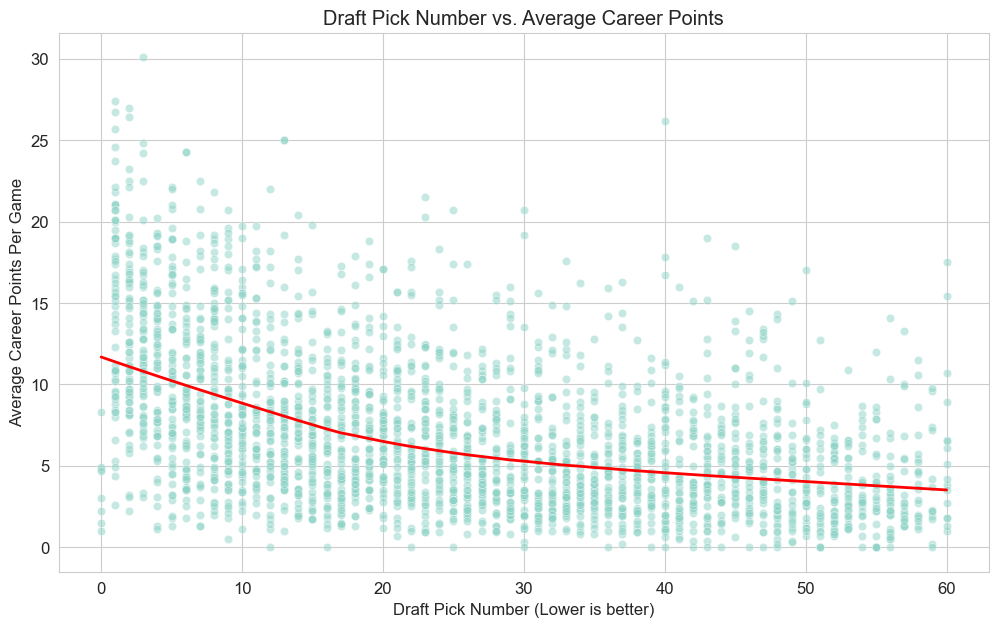

```
Note: This plot focuses on players with 'Career' stats and a valid draft number (<=60).
```

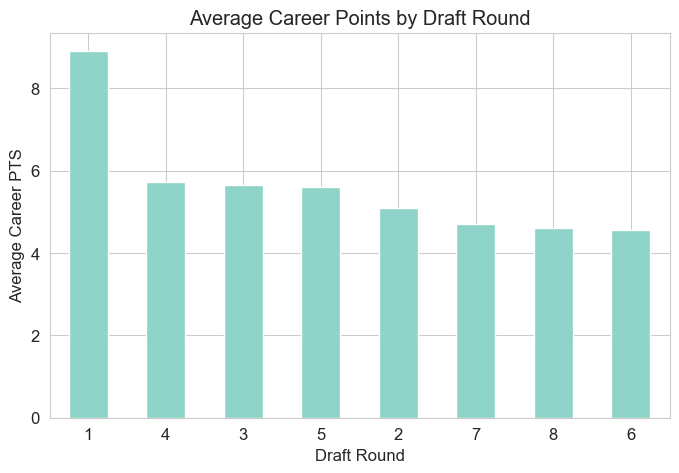

```python
# Relationship between Draft Number and Career Points
# Filter out obvious outliers or undrafted players for a cleaner plot if DRAFT_NUMBER is high
drafted_career_df = career_df[career_df['DRAFT_NUMBER'].notna() & (career_df['DRAFT_NUMBER'] <= 60)] # Typical draft has 60 picks

plt.figure(figsize=(12, 7))
sns.scatterplot(x='DRAFT_NUMBER', y='PTS', data=drafted_career_df, alpha=0.5)
# Add a trend line (lowess for non-linear trends)
sns.regplot(x='DRAFT_NUMBER', y='PTS', data=drafted_career_df, scatter=False, lowess=True, color='red', line_kws={'linewidth': 2})
plt.title('Draft Pick Number vs. Average Career Points')
plt.xlabel('Draft Pick Number (Lower is better)')
plt.ylabel('Average Career Points Per Game')
plt.show()
print("Note: This plot focuses on players with 'Career' stats and a valid draft number (<=60).")


# Average Career Points by Draft Round
drafted_career_df['DRAFT_ROUND'] = pd.to_numeric(drafted_career_df['DRAFT_ROUND'], errors='coerce').fillna(0).astype(int)
avg_pts_by_round = drafted_career_df[drafted_career_df['DRAFT_ROUND'] > 0].groupby('DRAFT_ROUND')['PTS'].mean().sort_values(ascending=False)

plt.figure(figsize=(8, 5))
avg_pts_by_round.plot(kind='bar')
plt.title('Average Career Points by Draft Round')
plt.xlabel('Draft Round')
plt.ylabel('Average Career PTS')
plt.xticks(rotation=0)
plt.show()
```

### 3.4 Physical Attributes vs. Performance

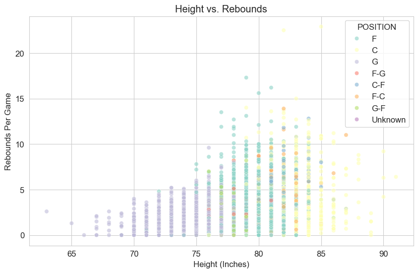

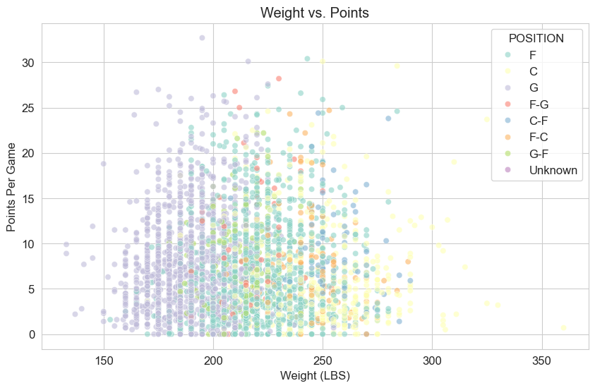

```python
# Height vs. Rebounds
plt.figure(figsize=(10,6))
sns.scatterplot(x='HEIGHT_INCHES', y='REB', data=df[df['HEIGHT_INCHES'].notna()], hue='POSITION', alpha=0.6)
plt.title('Height vs. Rebounds')
plt.xlabel('Height (Inches)')
plt.ylabel('Rebounds Per Game')
plt.show()


# Weight vs. Points
plt.figure(figsize=(10,6))
sns.scatterplot(x='WEIGHT_LBS', y='PTS', data=df[df['WEIGHT_LBS'].notna()], hue='POSITION', alpha=0.6)
plt.title('Weight vs. Points')
plt.xlabel('Weight (LBS)')
plt.ylabel('Points Per Game')
plt.show()
```

### 3.5 Geographical Diversity & College Impact

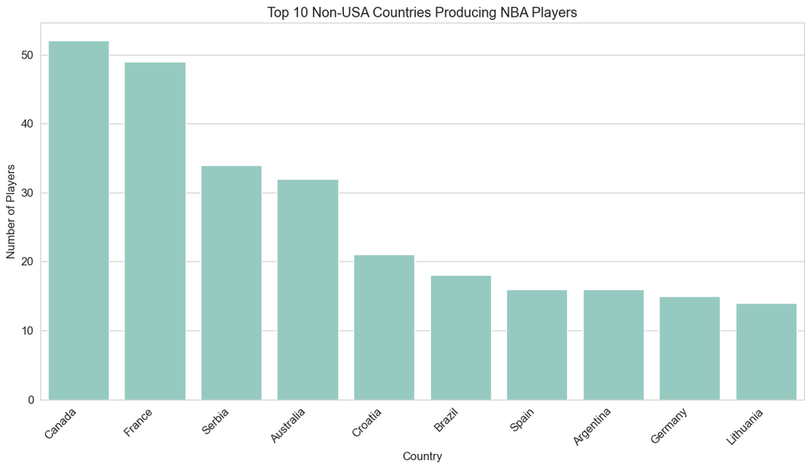

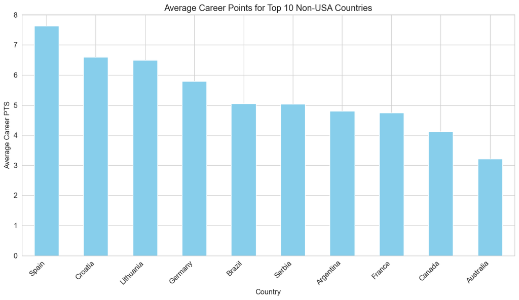

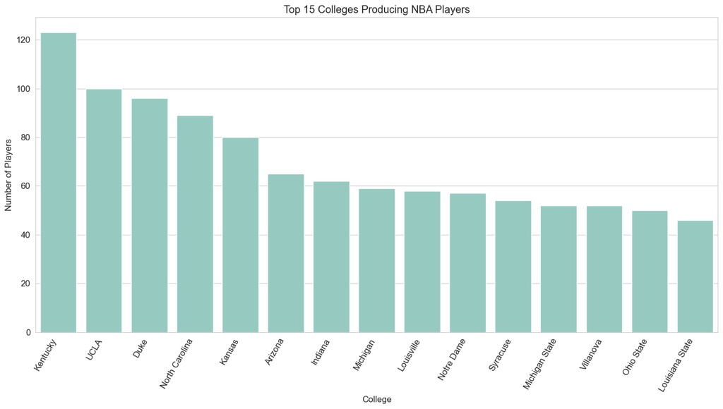

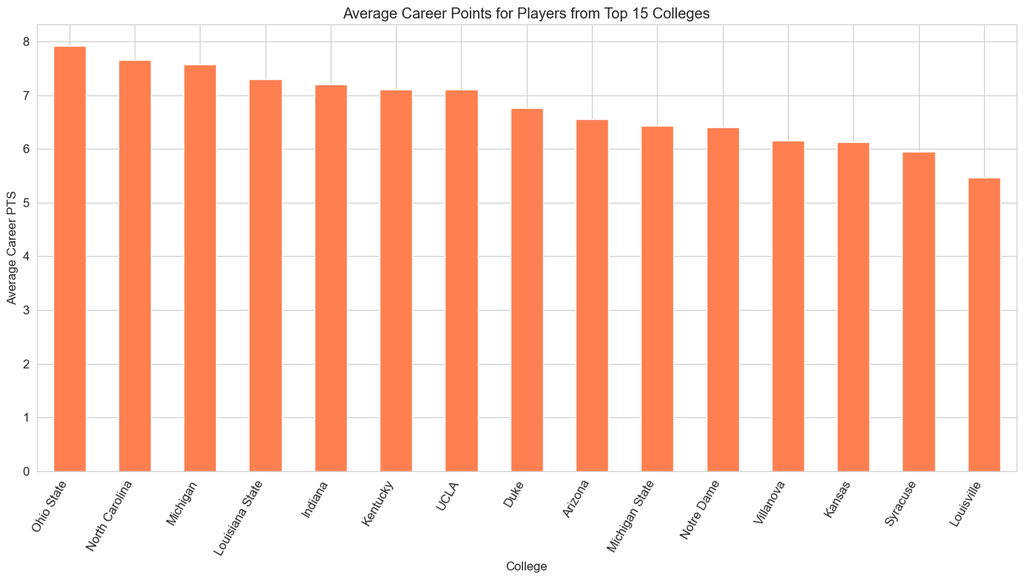

```python
# Top Countries (excluding USA for diversity view)
top_countries = df[df['COUNTRY'] != 'USA']['COUNTRY'].value_counts().nlargest(10)
plt.figure(figsize=(12, 7))
sns.barplot(x=top_countries.index, y=top_countries.values)
plt.title('Top 10 Non-USA Countries Producing NBA Players')
plt.xlabel('Country')
plt.ylabel('Number of Players')
plt.xticks(rotation=45, ha='right')
plt.tight_layout()
plt.show()


# Average career points for players from top non-USA countries
country_avg_pts = df[(df['COUNTRY'].isin(top_countries.index)) & (df['STATS_TIMEFRAME'] == 'Career')].groupby('COUNTRY')['PTS'].mean().sort_values(ascending=False)
plt.figure(figsize=(12, 7))
country_avg_pts.plot(kind='bar', color='skyblue')
plt.title('Average Career Points for Top 10 Non-USA Countries')
plt.xlabel('Country')
plt.ylabel('Average Career PTS')
plt.xticks(rotation=45, ha='right')
plt.tight_layout()
plt.show()


# Top Colleges producing NBA players
top_colleges = df[df['COLLEGE'] != 'Unknown']['COLLEGE'].value_counts().nlargest(15)
plt.figure(figsize=(14, 8))
sns.barplot(x=top_colleges.index, y=top_colleges.values)
plt.title('Top 15 Colleges Producing NBA Players')
plt.xlabel('College')
plt.ylabel('Number of Players')
plt.xticks(rotation=60, ha='right')
plt.tight_layout()
plt.show()


# Average career points for players from top colleges
college_avg_pts = df[(df['COLLEGE'].isin(top_colleges.index)) & (df['STATS_TIMEFRAME'] == 'Career')].groupby('COLLEGE')['PTS'].mean().sort_values(ascending=False)
plt.figure(figsize=(14, 8))
college_avg_pts.plot(kind='bar', color='coral')
plt.title('Average Career Points for Players from Top 15 Colleges')
plt.xlabel('College')
plt.ylabel('Average Career PTS')
plt.xticks(rotation=60, ha='right')
plt.tight_layout()
plt.show()
```

### 3.6 Current Season Standouts (Active Players - `STATS_TIMEFRAME == 'Season'`)

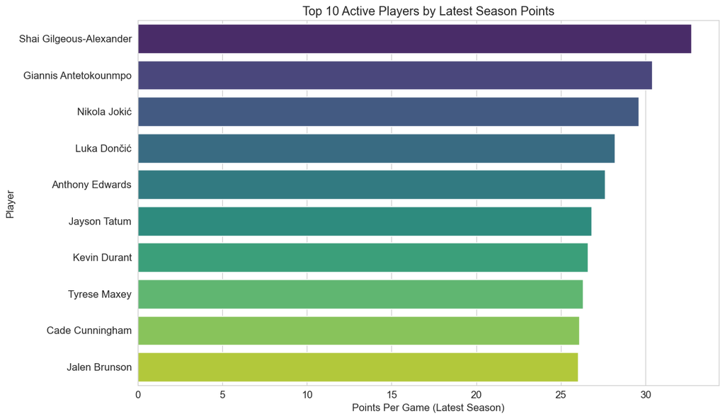

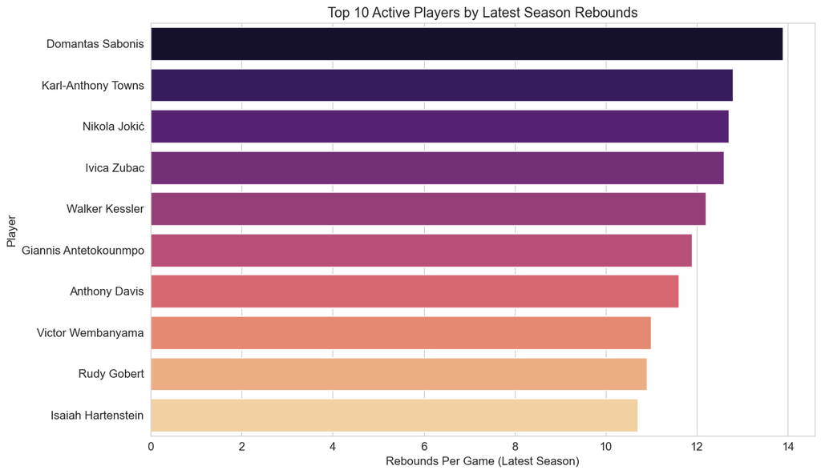

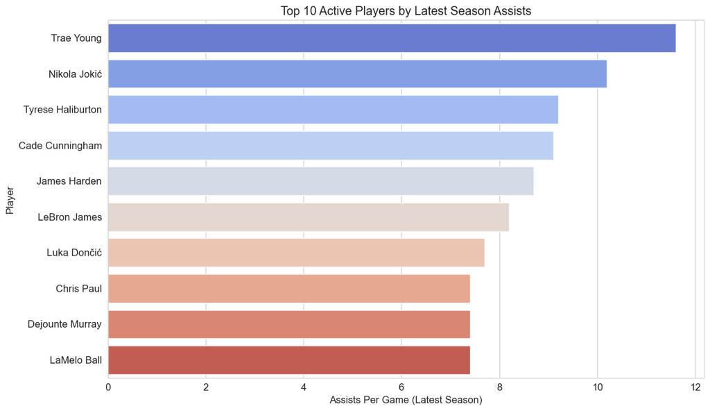

```python
# Top 10 active players by PTS in their latest season
top_season_pts = season_df.sort_values(by='PTS', ascending=False).head(10)
plt.figure(figsize=(12, 7))
sns.barplot(x='PTS', y='PLAYER_NAME', data=top_season_pts, palette='viridis', hue='PLAYER_NAME', dodge=False, legend=False)
plt.title('Top 10 Active Players by Latest Season Points')
plt.xlabel('Points Per Game (Latest Season)')
plt.ylabel('Player')
plt.tight_layout()
plt.show()


# Top 10 active players by REB in their latest season
top_season_reb = season_df.sort_values(by='REB', ascending=False).head(10)
plt.figure(figsize=(12, 7))
sns.barplot(x='REB', y='PLAYER_NAME', data=top_season_reb, palette='magma', hue='PLAYER_NAME', dodge=False, legend=False)
plt.title('Top 10 Active Players by Latest Season Rebounds')
plt.xlabel('Rebounds Per Game (Latest Season)')
plt.ylabel('Player')
plt.tight_layout()
plt.show()


# Top 10 active players by AST in their latest season
top_season_ast = season_df.sort_values(by='AST', ascending=False).head(10)
plt.figure(figsize=(12, 7))
sns.barplot(x='AST', y='PLAYER_NAME', data=top_season_ast, palette='coolwarm', hue='PLAYER_NAME', dodge=False, legend=False)
plt.title('Top 10 Active Players by Latest Season Assists')
plt.xlabel('Assists Per Game (Latest Season)')
plt.ylabel('Player')
plt.tight_layout()
plt.show()
```

## 4. SQL Query Demonstrations (using pandasql)

```python
# Query 1: Top 10 players by career points
query1 = """
SELECT PLAYER_NAME, PTS
FROM career_df
ORDER BY PTS DESC
LIMIT 10;
"""
top_career_scorers_sql = pysqldf(query1)
print("Top 10 Career Scorers (SQL):\n", top_career_scorers_sql)


# Query 2: Average points per game by position (all players)
query2 = """
SELECT POSITION, AVG(PTS) AS AVG_PTS
FROM df
WHERE POSITION != 'Unknown'
GROUP BY POSITION
ORDER BY AVG_PTS DESC;
"""
avg_pts_by_position_sql = pysqldf(query2)
print("\nAverage PTS by Position (SQL):\n", avg_pts_by_position_sql)


# Query 3: Players from Duke with > 15 career PPG
query3 = """
SELECT PLAYER_NAME, COLLEGE, PTS
FROM career_df
WHERE COLLEGE = 'Duke' AND PTS > 15
ORDER BY PTS DESC;
"""
duke_high_scorers_sql = pysqldf(query3)
print("\nDuke Players with > 15 Career PPG (SQL):\n", duke_high_scorers_sql)


# Query 4: Number of players and average DRAFT_NUMBER by DRAFT_YEAR (for players with 'Career' stats)
query4 = """
SELECT DRAFT_YEAR, COUNT(PERSON_ID) AS Num_Players, AVG(DRAFT_NUMBER) AS Avg_Draft_Pick
FROM career_df
WHERE DRAFT_YEAR IS NOT NULL AND DRAFT_NUMBER IS NOT NULL
GROUP BY DRAFT_YEAR
ORDER BY DRAFT_YEAR DESC
LIMIT 10;
"""
draft_year_summary_sql = pysqldf(query4)
print("\nDraft Year Summary (SQL, last 10 available years with career data):\n", draft_year_summary_sql)
```

```
Top 10 Career Scorers (SQL):
         PLAYER_NAME   PTS
0  Wilt Chamberlain  30.1
1    Michael Jordan  30.1
2      Elgin Baylor  27.4
3        Jerry West  27.0
4     Allen Iverson  26.7
5        Bob Pettit  26.4
6     George Gervin  26.2
7   Oscar Robertson  25.7
8       Kobe Bryant  25.0
9       Karl Malone  25.0

Average PTS by Position (SQL):
   POSITION   AVG_PTS
```

[output cut: 28 more lines]

## 5. Predictive Modeling: Career Points Per Game (PTS)

In this section, we'll attempt to build a model to predict a player's **Career Points Per Game (PTS)** based on information available around the time they entered the league (draft details, college, position, physical attributes).

**Target Variable:** `PTS` (for players with `STATS_TIMEFRAME == 'Career'`)

**Features:** `DRAFT_NUMBER`, `DRAFT_ROUND`, `HEIGHT_INCHES`, `WEIGHT_LBS`, `POSITION`, `COLLEGE`.

```python
from sklearn.model_selection import train_test_split
from sklearn.preprocessing import StandardScaler, OneHotEncoder
from sklearn.compose import ColumnTransformer
from sklearn.pipeline import Pipeline
from sklearn.linear_model import LinearRegression, Ridge
from sklearn.ensemble import RandomForestRegressor, GradientBoostingRegressor
from sklearn.metrics import mean_squared_error, r2_score
from sklearn.impute import SimpleImputer
```

### 5.1 Data Preparation for Modeling

```python
# Use the 'career_df' created earlier, which is df[df['STATS_TIMEFRAME'] == 'Career']
model_df = career_df.copy()
```

```python
# Select features and target
features = ['DRAFT_NUMBER', 'DRAFT_ROUND', 'HEIGHT_INCHES', 'WEIGHT_LBS', 'POSITION', 'COLLEGE']
target = 'PTS'
```

```python
# Filter out rows where essential features or target are missing for modeling
# DRAFT_NUMBER is crucial. Let's focus on drafted players.
model_df = model_df[model_df['DRAFT_NUMBER'].notna()]
model_df = model_df[model_df[target].notna()] # PTS should already be handled, but good check
```

```python
# For simplicity, we'll drop rows if HEIGHT_INCHES or WEIGHT_LBS are missing in this subset
model_df.dropna(subset=['HEIGHT_INCHES', 'WEIGHT_LBS'], inplace=True)

# Handle DRAFT_ROUND: Ensure it's numeric; fill NaNs for undrafted (though we filtered by DRAFT_NUMBER)
model_df['DRAFT_ROUND'] = pd.to_numeric(model_df['DRAFT_ROUND'], errors='coerce').fillna(0) # 0 for undrafted/unknown

# Reset index for clean processing
model_df.reset_index(drop=True, inplace=True)

X = model_df[features]
y = model_df[target]

print(f"Shape of X: {X.shape}, Shape of y: {y.shape}")
X.head()
```

```
Shape of X: (3010, 6), Shape of y: (3010,)
```

|  | DRAFT_NUMBER | DRAFT_ROUND | HEIGHT_INCHES | WEIGHT_LBS | POSITION | COLLEGE |
| --- | --- | --- | --- | --- | --- | --- |
| 0 | 25.0 | 1.0 | 82.0 | 240.0 | F | Duke |
| 1 | 5.0 | 1.0 | 81.0 | 235.0 | C | Iowa State |
| 2 | 1.0 | 1.0 | 86.0 | 225.0 | C | UCLA |
| 3 | 3.0 | 1.0 | 73.0 | 162.0 | G | Louisiana State |
| 4 | 11.0 | 1.0 | 78.0 | 235.0 | F-G | San Jose State |

```python
X.isnull().sum() # Check for NaNs in features before preprocessing
```

```
DRAFT_NUMBER     0
DRAFT_ROUND      0
HEIGHT_INCHES    0
WEIGHT_LBS       0
POSITION         0
COLLEGE          0
dtype: int64
```

### 5.2 Feature Preprocessing and Pipeline Setup

```python
# Identify categorical and numerical features
categorical_features = ['POSITION', 'COLLEGE']
numerical_features = ['DRAFT_NUMBER', 'DRAFT_ROUND', 'HEIGHT_INCHES', 'WEIGHT_LBS']

# Preprocessing for numerical features: Impute NaNs (if any) and scale
numerical_transformer = Pipeline(steps=[
    ('imputer', SimpleImputer(strategy='median')), # Handles any stray NaNs
    ('scaler', StandardScaler())
])

# Preprocessing for categorical features: Impute NaNs and one-hot encode
# For 'COLLEGE', there are many unique values. We'll use handle_unknown='ignore'
# which means if a college seen in test wasn't in train, its OHE columns will be all zeros.
# A more robust approach for 'COLLEGE' might involve feature hashing or limiting to top N colleges.
categorical_transformer = Pipeline(steps=[
    ('imputer', SimpleImputer(strategy='constant', fill_value='Unknown')),
    ('onehot', OneHotEncoder(handle_unknown='ignore', sparse_output=False))
])

# Create a column transformer to apply different transformations to different columns
preprocessor = ColumnTransformer(
    transformers=[
        ('num', numerical_transformer, numerical_features),
        ('cat', categorical_transformer, categorical_features)
    ],
    remainder='passthrough' # Keep other columns (if any)
)
```

### 5.3 Train-Test Split

```python
X_train, X_test, y_train, y_test = train_test_split(X, y, test_size=0.2, random_state=42)

print(f"X_train shape: {X_train.shape}, X_test shape: {X_test.shape}")
print(f"y_train shape: {y_train.shape}, y_test shape: {y_test.shape}")
```

```
X_train shape: (2408, 6), X_test shape: (602, 6)
y_train shape: (2408,), y_test shape: (602,)
```

### 5.4 Model Training and Evaluation

```python
# Define models to train
models = {
    "Linear Regression": LinearRegression(),
    "Ridge Regression": Ridge(alpha=1.0),
    "Random Forest Regressor": RandomForestRegressor(n_estimators=100, random_state=42, n_jobs=-1, max_depth=10, min_samples_split=10),
    "Gradient Boosting Regressor": GradientBoostingRegressor(n_estimators=100, random_state=42, max_depth=5)
}

results = {}

for name, model in models.items():
    print(f"Training {name}...")
    # Create the full pipeline: preprocessor + model
    pipeline = Pipeline(steps=[('preprocessor', preprocessor),
                               ('regressor', model)])

    pipeline.fit(X_train, y_train)
    y_pred = pipeline.predict(X_test)

    rmse = np.sqrt(mean_squared_error(y_test, y_pred))
    r2 = r2_score(y_test, y_pred)

    results[name] = {'RMSE': rmse, 'R2 Score': r2}
    print(f"{name} - RMSE: {rmse:.4f}, R2 Score: {r2:.4f}\n")


# Display results
results_df = pd.DataFrame(results).T.sort_values(by='R2 Score', ascending=False)
print("Model Performance Summary:")
print(results_df)
```

```
Training Linear Regression...
Linear Regression - RMSE: 4.4395, R2 Score: 0.0745

Training Ridge Regression...
Ridge Regression - RMSE: 4.3185, R2 Score: 0.1243

Training Random Forest Regressor...
Random Forest Regressor - RMSE: 3.9918, R2 Score: 0.2518

Training Gradient Boosting Regressor...
Gradient Boosting Regressor - RMSE: 4.0023, R2 Score: 0.2478

Model Performance Summary:
                                 RMSE  R2 Score
Random Forest Regressor      3.991784  0.251754
Gradient Boosting Regressor  4.002261  0.247821
Ridge Regression             4.318512  0.124254
Linear Regression            4.439528  0.074485
```

### 5.5 Feature Importances (for tree-based models)

Let's look at feature importances from the Random Forest Regressor, which often performs well.

```
Top 20 Feature Importances (Random Forest):
                      feature  importance
0                DRAFT_NUMBER    0.582012
2               HEIGHT_INCHES    0.039265
3                  WEIGHT_LBS    0.036991
1                 DRAFT_ROUND    0.017066
121  COLLEGE_Eastern Michigan    0.014176
9                  POSITION_G    0.012894
258    COLLEGE_North Carolina    0.009230
203    COLLEGE_Louisiana Tech    0.007947
176     COLLEGE_Indiana State    0.007173
182      COLLEGE_Jacksonville    0.007045
144      COLLEGE_Gardner-Webb    0.006637
274        COLLEGE_Notre Dame    0.005701
4                  POSITION_C    0.005602
156          COLLEGE_Guilford    0.005532
252  COLLEGE_New Mexico State    0.005111
65      COLLEGE_Buffalo State    0.004914
384         COLLEGE_Tennessee    0.004706
344    COLLEGE_South Carolina    0.004582
35             COLLEGE_Auburn    0.004376
223           COLLEGE_Memphis    0.004340
```

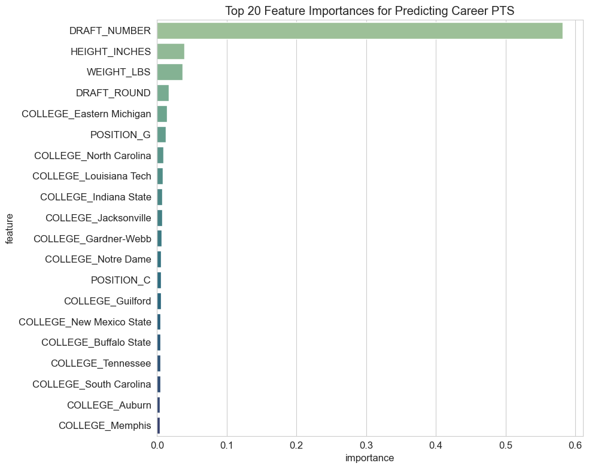

```python
# Get the trained Random Forest pipeline
rf_pipeline = Pipeline(steps=[('preprocessor', preprocessor),
                              ('regressor', RandomForestRegressor(n_estimators=100, random_state=42, n_jobs=-1, max_depth=10, min_samples_split=10))])
rf_pipeline.fit(X_train, y_train) # Fit again to ensure we have the fitted preprocessor

# Get feature names after one-hot encoding
# The preprocessor must be fitted first to get feature names
# We access the 'onehot' step from the 'cat' transformer within the 'preprocessor'
try:
    ohe_feature_names = rf_pipeline.named_steps['preprocessor'].named_transformers_['cat'].named_steps['onehot'].get_feature_names_out(categorical_features)
    all_feature_names = numerical_features + list(ohe_feature_names)
except Exception as e:
    print(f"Error getting OHE feature names: {e}")
    all_feature_names = None # Fallback

if all_feature_names and hasattr(rf_pipeline.named_steps['regressor'], 'feature_importances_'):
    importances = rf_pipeline.named_steps['regressor'].feature_importances_

    feature_importance_df = pd.DataFrame({'feature': all_feature_names, 'importance': importances})
    feature_importance_df = feature_importance_df.sort_values(by='importance', ascending=False)

    print("\nTop 20 Feature Importances (Random Forest):")
    print(feature_importance_df.head(20))

    plt.figure(figsize=(10, 8))
    sns.barplot(x='importance', y='feature', data=feature_importance_df.head(20), palette='crest', hue='feature', dodge=False, legend=False)
    plt.title('Top 20 Feature Importances for Predicting Career PTS')
    plt.tight_layout()
    plt.show()
else:
    print("Could not retrieve feature importances. Ensure the model is a tree-based model and preprocessor is fitted.")
```

### 5.6 Model Interpretation and Limitations

**Interpretation:**

- The R-squared value tells us the proportion of the variance in career PTS that can be explained by our features. Higher is better.
- RMSE (Root Mean Squared Error) gives us an idea of the typical error in our PTS predictions, in the same units as PTS. Lower is better.
- Feature importances highlight which factors (like draft number, height, specific colleges/positions) the model found most influential in predicting career points. `DRAFT_NUMBER` is often a very strong predictor.

**Limitations:**

- **Data Granularity:** We are predicting *career average* PTS. This smooths out year-to-year variations and doesn't capture the peak performance or longevity aspects directly as a target.
- **College Feature:** The `COLLEGE` feature has high cardinality. While OneHotEncoder with `handle_unknown='ignore'` is a start, more advanced techniques like target encoding (with careful cross-validation to prevent leakage), embedding layers, or grouping colleges by conference/tier could improve performance or interpretability. For this example, we used basic OHE.
- **"Talent Not Captured":** Many intangible factors (work ethic, injury luck, coaching, team fit) that significantly impact a player's career are not present in this dataset.
- **Model Complexity:** More complex models might yield slightly better R-squared values but could be harder to interpret and prone to overfitting if not carefully tuned.
- **Definition of "Performance":** PTS is just one aspect of performance. A more holistic measure (like PER or Win Shares, if available) could be a more comprehensive target, but this dataset focuses on basic box score stats.

This predictive modeling exercise serves as a demonstration of applying machine learning techniques to sports data. The results should be viewed as exploratory rather than definitive predictions of player success.